# DS400: Assignment IV (R)

Mohamed Elsherif (Student ID: 6378374)

2025-01-20

### Directory set up & Libraries Installation

```r
# Load all libraries needed
suppressWarnings(suppressPackageStartupMessages(library(httr)))
suppressWarnings(suppressPackageStartupMessages(library(jsonlite)))
suppressWarnings(suppressPackageStartupMessages(library(dplyr)))
suppressWarnings(library(ggplot2))
suppressWarnings(library(scales))
suppressWarnings(library(rvest))
suppressWarnings(library(tidyr))
options(warn = -1)
```

## Open-Meteo APIs

#### 1. Use the Open-Meteo geocoding API to retrieve the coordinates for Tübingen.

```r
# Open-Meteo Geocoding API URL
url <- "https://geocoding-api.open-meteo.com/v1/search"

# Parameters for the request
params <- list(
  name = "Tübingen",
  language = "en",
  count = 1
)

# Send request
response <- GET(url, query = params)

# Parse response JSON
data <- fromJSON(content(response, "text"))

# Save coordinates
latitude <- data$results$latitude
longitude <- data$results$longitude
```

#### 2. Print the coordinates (longitude and latitude).

```r
# Print coordinates
print(paste("Coordinates for Tübingen: Latitude =", latitude, ", Longitude =", longitude))
```

```
## [1] "Coordinates for Tübingen: Latitude = 48.52266 , Longitude = 9.05222"
```

#### 3. Retrieve the historic weather data for Tübingen from 1940 to 2024 and store the data in a data frame.

```r
# URL for Open-Meteo Historical Weather API
url <- "https://archive-api.open-meteo.com/v1/era5"

# Initialize empty list to store weather data
weather_data <- list()

# Loop through each year from 1940 to 2024
for (year in 1940:2024) {
  # Request parameters
  params <- list(
    latitude = latitude,
    longitude = longitude,
    start_date = paste0(year, "-01-01"),
    end_date = paste0(year, "-12-31"),
    hourly = "temperature_2m",
    temperature_unit = "celsius",
    timezone = "Europe/Berlin"
  )

  # Send request
  response <- GET(url, query = params)

  # Parse JSON response
  data <- fromJSON(content(response, "text"))

  # Extract temperature data and time
  temperatures <- data$hourly$temperature_2m
  dates <- data$hourly$time

  # Create a data frame with Dates
  df <- data.frame(
    Date = as.POSIXct(dates, format = "%Y-%m-%dT%H:%M"),
    Temperature = temperatures
  )

  # Append data frame to the list
  weather_data[[as.character(year)]] <- df
}


# Combine all data frames into one
all_data <- bind_rows(weather_data)
```

#### 4. Compute the yearly average temperatures. Print the first five rows of the data frame.

```r
# Compute yearly average temperature
yearly_avg_temperatures <- all_data %>%
  mutate(Year = format(Date, "%Y")) %>%
  group_by(Year) %>%
  summarize(Temperature = mean(Temperature, na.rm = TRUE))

# Show collected data
print(head(yearly_avg_temperatures, 5))
```

```
## # A tibble: 5 × 2
##   Year  Temperature
##   <chr>       <dbl>
## 1 1940         7.43
## 2 1941         7.85
## 3 1942         8.31
## 4 1943         9.81
## 5 1944         8.86
```

#### 5. Create a “temperature anomaly” plot. It should look as close as possible like the one shown below.The temperature anomaly is the difference between the yearly average temperature and the average temperature over a specific period. Here, we choose the period of 1991–2020 (similar to the one from Our World in Data). The plot should show the temperature anomalies for Tübingen from 1940 to 2024 (with the average temperature of 1991–2020 as the reference).

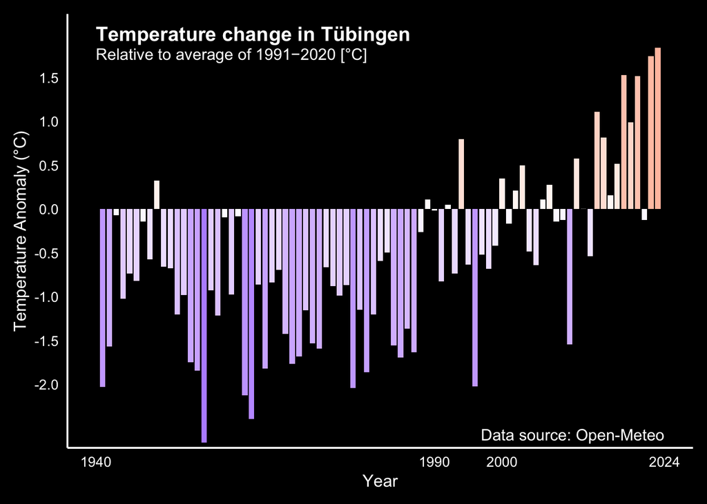

```r
# Calculate reference period average (1991–2020)
reference_period <- yearly_avg_temperatures %>%
  filter(Year >= 1991 & Year <= 2020)

reference_avg_temp <- mean(reference_period$Temperature, na.rm = TRUE)

# Calculate temperature anomaly
yearly_avg_temperatures <- yearly_avg_temperatures %>%
  mutate(
    Temperature_Anomaly = Temperature - reference_avg_temp,
    Year = as.numeric(Year) # Convert Year to numeric for proper axis plotting
  )

# Plot
ggplot(yearly_avg_temperatures, aes(x = Year, y = Temperature_Anomaly, fill = Temperature_Anomaly)) +
  geom_bar(stat = "identity", width = 0.8, show.legend = FALSE) +  # Keep all data
  scale_fill_gradient2(
    low = "blue", mid = "white", high = "red",
    midpoint = 0
  ) +
  labs(
    x = "Year",
    y = "Temperature Anomaly (°C)"
  ) +
  theme_minimal(base_size = 14) +
  theme(
    plot.background = element_rect(fill = "black", color = NA),
    panel.background = element_rect(fill = "black", color = NA),
    panel.grid = element_blank(),
    axis.text = element_text(color = "white", size = 10),
    axis.title = element_text(color = "white", size = 12),
    legend.position = "none",
    plot.caption = element_text(color = "white", hjust = 1, size = 8),
    axis.line = element_line(color = "white"),
    plot.margin = margin(t = 10, r = 10, b = 10, l = 10)
  ) +
  # Set y-axis limits
  scale_y_continuous(
    breaks = seq(-2, 1.5, 0.5),
    limits = c(-2.5, 2),
    oob = scales::oob_keep
  ) +
  # Add x-axis ticks
  scale_x_continuous(
    breaks = c(1940, 1990, 2000, 2024),
    limits = c(1940, 2024)
  ) +
  # Add title and subtitle
  annotate(
    "text", x = 1940, y = 2, label = "Temperature change in Tübingen",
    hjust = 0, color = "white", size = 5, fontface = "bold"
  ) +
  annotate(
    "text", x = 1940, y = 1.77, label = "Relative to average of 1991−2020 [°C]",
    hjust = 0, color = "white", size = 4
  ) +
  # Add data source
  annotate(
    "text", x = 2024, y = -2.57, label = "Data source: Open-Meteo",
    hjust = 1, color = "white", size = 4
  )
```

## Web Scraping

#### 6. Scrape the repository name, the repository URL, the repository’s short description, the number of stars, and the last updated date for the first 20 repositories on the GitHub machine-learning topic page. Put the scraped data into a data frame. Print the entire data frame.

```r
# GitHub page URL
url <- "https://github.com/topics/machine-learning"

# Fetch page content
page <- read_html(url)

# XPath for repository names
repo_names <- page %>% html_nodes(xpath = '//*[contains(concat(" ", @class, " "), " wb-break-word ")]') %>% html_text()

# XPath for repository descriptions
repo_descriptions <- page %>% html_nodes(xpath = '//*[contains(concat(" ", @class, " "), " color-fg-muted ") and contains(concat(" ", @class, " "), " mb-0 ")]') %>% html_text()

# XPath for last updated dates
last_updated <- page %>% html_nodes(xpath = '//*[contains(concat(" ", @class, " "), " color-fg-muted ")]//*[contains(concat(" ", @class, " "), " no-wrap ")]') %>% html_text()

# XPath for stars count
stars <- page %>% html_nodes(xpath = '(//*[contains(concat(" ", @class, " "), " btn ")]//span[not(contains(text(), "Star")) and not(contains(text(), "All")) and not(contains(text(), "Most"))])[position() <= 21]') %>% html_text()

# Function to convert stars (k, M to numeric)
numberize_stars <- function(star_value) {
  if (grepl("k", star_value)) {
    return(as.numeric(gsub("k", "", star_value)) * 1000)
  } else if (grepl("M", star_value)) {
    return(as.numeric(gsub("M", "", star_value)) * 1000000)
  } else {
    return(as.numeric(star_value))
  }
}

# Clean the star count text and convert to numeric values
stars_clean <- sapply(stars, numberize_stars)

# Combine data into a data frame
repositories <- data.frame(
  Name = repo_names,
  Description = repo_descriptions,
  Last_Updated = last_updated,
  Stars = stars_clean,
  stringsAsFactors = FALSE
)

# Show data frame
print(repositories)
```

```
##                                                Name
## 187k                                     tensorflow
## 138k                                   transformers
## 86k                                         pytorch
## 73k                                         netdata
## 70.7k                              ML-For-Beginners
## 67.9k                              cs-video-courses
## 65.2k                                        d2l-zh
## 63.9k                                     tesseract
## 62.4k                                         keras
## 60.8k                                  scikit-learn
## 60k                             awesome-scalability
## 58.1k annotated_deep_learning_paper_implementations
## 54k                                face_recognition
## 52.9k                                      faceswap
## 52k                                          yolov5
## 46.2k                                         julia
## 46.1k                           100-Days-Of-ML-Code
## 43.5k                           TensorFlow-Examples
## 42.8k                                    llm-course
## 38.4k                                       airflow
##                                                                                                                                                                                                                                                                                                    Descri…
## 187k                                                                                                                                                                                                                                                    An Open Source Machine Learning Framework for Eve…
## 138k                                                                                                                                                                                                                      🤗 Transformers: State-of-the-art Machine Learning for Pytorch, TensorFlow, and …
## 86k                                                                                                                                                                                                                                 Tensors and Dynamic neural networks in Python with strong GPU acceler…
## 73k                                                                                                                                                                                                                    Architected for speed. Automated for easy. Monitoring and troubleshooting, transfo…
```

[output cut: 37 more lines]

#### 7. Visualize the popularity of these repositories by creating a bar plot showing the number of stars of the top 10 repositories. The plot should look similar to the one shown below.

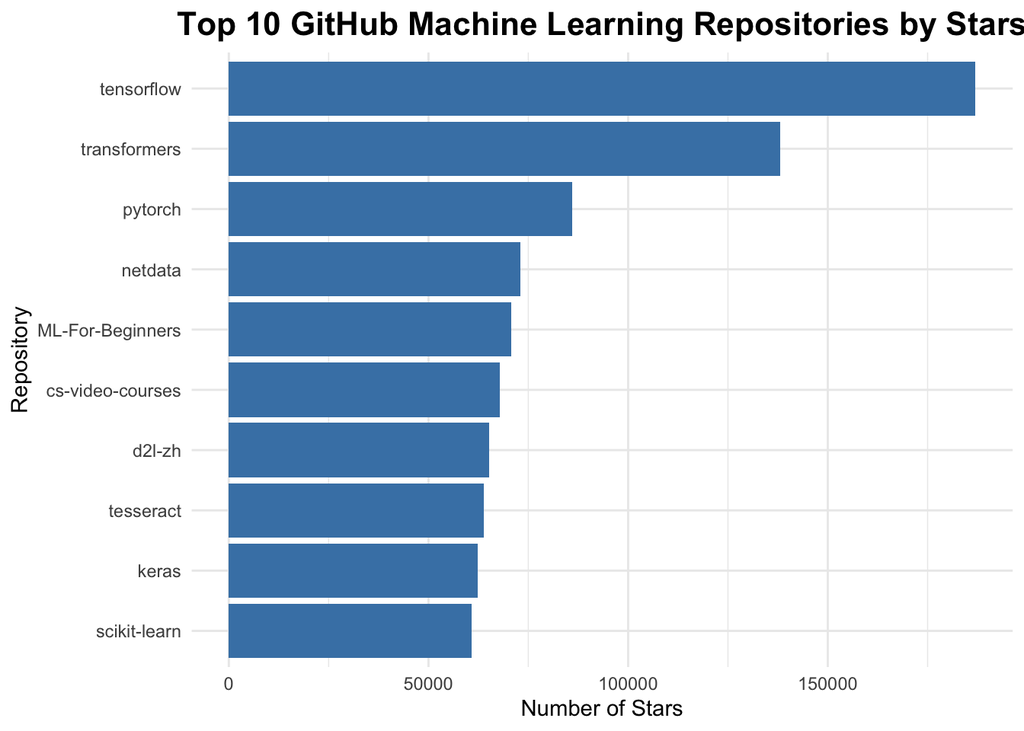

[output not shown]

```r
# Sort repositories by stars and select top 10
top_10_repositories <- repositories %>% arrange(desc(Stars)) %>% head(10)


# Bar plot for the top 10 repositories by Stars
ggplot(top_10_repositories, aes(y = reorder(Name, Stars), x = Stars)) +
  geom_bar(stat = "identity", fill = "steelblue") +
  labs(title = "Top 10 GitHub Machine Learning Repositories by Stars",
       y = "Repository", x = "Number of Stars") +
  theme(axis.text.y = element_text(angle = 0, hjust = 1)) +
  scale_y_discrete(labels = function(x) strtrim(x, 40)) +
  theme_minimal() +
  # Set x-ticks at every 50,000 interval excluding 200,000
  scale_x_continuous(breaks = function(x) seq(0, max(x), by = 50000)[seq(0, max(x), by = 50000) != 200000]) +
  # The title
  theme(plot.title = element_text(hjust = 0.5, face = "bold", size = 16))
```